# Text Analysis (2): Supervised Machine Learning

J381M Week 5 Tutorial - Instructor Version

Instructor: Sungwon Jung

February 12, 2026

# Before We Begin: Setup

## Install Required Packages

Students should have done this BEFORE class:

```r
install.packages(c(
  "tidyverse",
  "tidytext",
  "tidymodels",
  "textrecipes",
  "stopwords"
))
```

## Load Packages

```r
library(tidyverse)
library(tidytext)
library(textrecipes)
library(tidymodels)

cat("Packages loaded!\n")
```

```
## Packages loaded!
```

## Quick Test

```r
test_data <- tibble(
  text = c("I love this", "This is bad", "Pretty good"),
  rating = c(5, 1, 4)
)

test_data %>%
  unnest_tokens(word, text) %>%
  head()
```

```
## # A tibble: 6 × 2
##   rating word
##    <dbl> <chr>
## 1      5 i
## 2      5 love
## 3      5 this
## 4      1 this
## 5      1 is
## 6      1 bad
```

```r
cat("\nEverything works!\n")
```

```
##
## Everything works!
```

# Part 1: Core ML Principles

## What is Supervised Learning?

**KEY CONCEPT:** Supervised Learning = Learning from labeled examples

- Like learning with flashcards: Front (review text) → Back (correct answer)
- The machine learns patterns from examples WE provide
- It’s “supervised” because WE tell it what the correct answers are

**Real-world analogy:** Teaching a child to identify animals by showing pictures and saying “this is a dog”, “this is a cat”

## Two Main Tasks

### 1. Classification (Predicting Categories)

**What SML does:** Learns rules to put things into categories

**Examples:** - Is this review positive or negative? - Is this email spam or not spam? - Which topic does this article discuss?

**Output:** Labels/categories (positive, negative, spam, politics, sports)

**Today we’ll do:** Positive vs Negative sentiment

### 2. Regression (Predicting Numbers)

**What SML does:** Learns rules to predict a number

**Examples:** - What rating (1-5 stars) will this review give? - How much will this house sell for?

**Output:** Continuous numbers (3.7 stars, $450,000)

## Train/Test Split

**CRITICAL CONCEPT:** Never test on data you trained on!

**Explain with analogy:** - Would you study for an exam using the exact same questions that will be on the test? - That’s memorization, not learning! - Same with ML - we need to test on NEW data the model hasn’t seen

```
Total Data (100%)
│
├─ Training Set (75%)    ← Model learns patterns here
└─ Test Set (25%)        ← Evaluate on NEW data here
```

**Why 75/25?** - **75% training**: Need enough data to learn good patterns - **25% testing**: Need enough data to reliably evaluate - Common standard in ML (also see 80/20, 70/30) - Balance: More training = better learning, but need enough test data for evaluation

**IMPORTANT:** Test set is LOCKED AWAY until final evaluation. Never touch it during training!

### Dealing with Imbalanced Data

**Real-world problem:** Classes often unequal (e.g., 71% negative, 29% positive)

**Why it matters:** - A “dumb” model that always predicts the majority class gets 71% accuracy! - Our model must do BETTER than this baseline

**Solution: Stratified Sampling** - Keep same proportions in both train and test sets - If data is 70/30, training is also 70/30, test is also 70/30

**Mathematical principles:** (Beyond today’s scope, but important to know) - Prevents biased evaluation - Ensures representative samples - Critical for real-world applications

**What we’ll do:** Use `strata = sentiment` parameter to maintain proportions

# Part 2: Text as Features

## The Problem

Computers don’t understand words - they only understand numbers!

**We need to convert:** “This product is amazing!” → [0.3, 0.8, 0.0, 0.9, …]

## The Pipeline (Quick Review)

```
"This product is amazing!"
    ↓ TOKENIZATION (split into words)
["This", "product", "is", "amazing"]
    ↓ REMOVE STOP WORDS (remove common words)
["product", "amazing"]
    ↓ VECTORIZATION (convert to numbers)
[product: 1, amazing: 1, ...]
```

### Key Concepts

**1. Tokenization:** Split text into individual words

**2. Stop Words:** Common words with little meaning - Examples: “the”, “a”, “is”, “and” - We covered this last week!

**3. Vectorization:** Converting words to numbers - **Simplest:** Count how many times each word appears - **Better:** TF-IDF (what we’ll use today)

### TF-IDF (Important but Technical)

**Explain simply:** - TF (Term Frequency): How often does this word appear in THIS review? - IDF (Inverse Document Frequency): How rare is this word ACROSS ALL reviews? - TF-IDF = TF × IDF: Highlights words that are frequent in one review but rare overall

**Example:** - “amazon” appears in EVERY review → Low TF-IDF (not useful for classification) - “excellent” appears ONLY in positive reviews → High TF-IDF (very useful!)

# Part 3: Loading and Preparing Data

## Load Dataset

**What we’re doing:** Loading Amazon reviews from CSV

```r
amazon_reviews_raw <- read_csv(
  "Amazon_Reviews.csv",
  col_types = cols(
    `Reviewer Name` = col_character(),
    Country = col_character(),
    Rating = col_character(),
    `Review Title` = col_character(),
    `Review Text` = col_character(),
    .default = col_character()
  )
)

cat("Total reviews:", nrow(amazon_reviews_raw), "\n")
```

```
## Total reviews: 21055
```

“We have about 21,000 customer reviews of Amazon.com service”

## Clean Data

**What we’re doing:** Preparing data for analysis

```r
amazon_reviews_clean <- amazon_reviews_raw %>%
  rename(
    rating_text = Rating,
    review_text = `Review Text`
  ) %>%
  mutate(rating = as.numeric(str_extract(rating_text, "\\d+"))) %>%
  filter(
    !is.na(review_text),
    review_text != "",
    !is.na(rating),
    rating >= 1 & rating <= 5
  ) %>%
  mutate(
    word_count = str_count(review_text, "\\w+"),
    sentiment = case_when(
      rating >= 4 ~ "positive",
      rating <= 2 ~ "negative",
      TRUE ~ "neutral"
    )
  )

cat("After cleaning:", nrow(amazon_reviews_clean), "reviews\n")
```

```
## After cleaning: 21055 reviews
```

**Explain quickly:** - Extract rating number (1-5) from text - Remove empty/invalid reviews - Count words in each review - Create sentiment labels: 4-5 stars = positive, 1-2 = negative, 3 = neutral

## Prepare Datasets

**What we’re doing:** Creating two versions of data

```r
# CLASSIFICATION: Binary sentiment (pos vs neg)
amazon_classification <- amazon_reviews_clean %>%
  filter(sentiment != "neutral") %>%
  mutate(sentiment = factor(sentiment, levels = c("negative", "positive"))) %>%
  select(review_text, sentiment, rating, word_count)

# REGRESSION: Predict rating (1-5) - for self-learning
amazon_regression <- amazon_reviews_clean %>%
  select(review_text, rating, sentiment, word_count)

cat("Classification dataset:", nrow(amazon_classification), "reviews\n")
```

```
## Classification dataset: 20170 reviews
```

```r
cat("Regression dataset:", nrow(amazon_regression), "reviews\n")
```

```
## Regression dataset: 21055 reviews
```

- Classification: Remove 3-star (neutral) reviews - focus on clear positive/negative
- Regression: Keep all ratings - will use for self-learning later

## Example Reviews

Example reviews:

```r
set.seed(2025)

cat("=== POSITIVE Examples ===\n\n")
```

```
## === POSITIVE Examples ===
```

```r
amazon_classification %>%
  filter(sentiment == "positive") %>%
  slice_sample(n = 2) %>%
  pull(review_text) %>%
  str_trunc(200) %>%
  paste0(1:2, ". ", .) %>%
  cat(sep = "\n\n")
```

```
## 1. Let me down few time but overall great, especially prime deliveries next day or sometimes even same day before 10pm.
##
## 2. Great customer service, whenever there is an issue they resolve it. I have bought many things from Amazon.
```

```r
cat("\n\n=== NEGATIVE Examples ===\n\n")
```

```
##
##
## === NEGATIVE Examples ===
```

```r
amazon_classification %>%
  filter(sentiment == "negative") %>%
  slice_sample(n = 2) %>%
  pull(review_text) %>%
  str_trunc(200) %>%
  paste0(1:2, ". ", .) %>%
  cat(sep = "\n\n")
```

```
## 1. Very bad servicebad experience
##
## 2. Pick up the phone with so loud background noisy; got my information then put me on the ugly to hell music and disappeared for more than 10 min.... such a dirty business and need to cancel the prime...
```

# Part 4: CLASSIFICATION

## Train/Test Split

**CRITICAL CONCEPT:** Never test on data you trained on!

**Explain with analogy:** - Would you study for an exam using the exact same questions that will be on the test? - That’s memorization, not learning! - Same with ML - we need to test on NEW data the model hasn’t seen

```
Total Data (100%)
│
├─ Training Set (75%)    ← Model learns patterns here
└─ Test Set (25%)        ← Evaluate on NEW data here
```

**Why 75/25?** - **75% training**: Need enough data to learn good patterns - **25% testing**: Need enough data to reliably evaluate - Common standard in ML (also see 80/20, 70/30) - Balance: More training = better learning, but need enough test data for evaluation

**IMPORTANT:** Test set is LOCKED AWAY until final evaluation. Never touch it during training!

### Dealing with Imbalanced Data

**Real-world problem:** Classes often unequal (e.g., 71% negative, 29% positive)

**Why it matters:** - A “dumb” model that always predicts the majority class gets 71% accuracy! - Our model must do BETTER than this baseline

**Solution: Stratified Sampling** - Keep same proportions in both train and test sets - If data is 70/30, training is also 70/30, test is also 70/30

**Mathematical principles:** (Beyond today’s scope, but important to know) - Prevents biased evaluation - Ensures representative samples - Critical for real-world applications

**What we’ll do:** Use `strata = sentiment` parameter to maintain proportions

## Visualize the Data

**Why visualize:** Need to understand our data before building a model

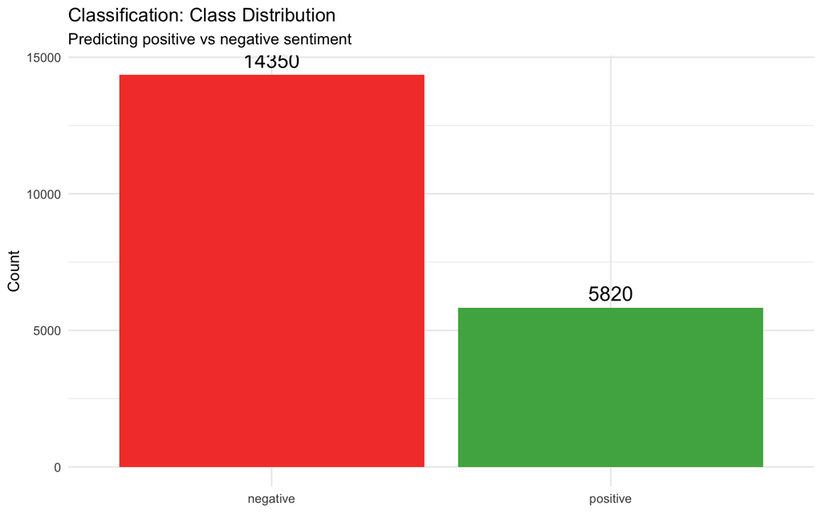

```r
# Class distribution
ggplot(amazon_classification, aes(x = sentiment, fill = sentiment)) +
  geom_bar() +
  geom_text(stat = "count", aes(label = after_stat(count)), vjust = -0.5, size = 5) +
  labs(title = "Classification: Class Distribution",
       subtitle = "Predicting positive vs negative sentiment",
       x = NULL, y = "Count") +
  scale_fill_manual(values = c("negative" = "#F44336", "positive" = "#4CAF50")) +
  theme_minimal() +
  theme(legend.position = "none")
```

```r
# Check class balance
class_dist <- amazon_classification %>%
  count(sentiment) %>%
  mutate(pct = round(n/sum(n)*100, 1))

print(class_dist)
```

```
## # A tibble: 2 × 3
##   sentiment     n   pct
##   <fct>     <int> <dbl>
## 1 negative  14350  71.1
## 2 positive   5820  28.9
```

```r
neg_count <- class_dist %>% filter(sentiment == "negative") %>% pull(n)
pos_count <- class_dist %>% filter(sentiment == "positive") %>% pull(n)
imbalance_ratio <- round(neg_count / pos_count, 1)
```

**CLASS IMBALANCE DETECTED!**

- **Ratio**: 2.5 : 1 (negative : positive)
- **Negative**: 71.1% | **Positive**: 28.9%
- Our data is imbalanced: More negative reviews than positive
- A “dumb” model that always says “negative” gets 71.1% accuracy
- Our model MUST beat this baseline!
- We’ll use stratified sampling to handle this

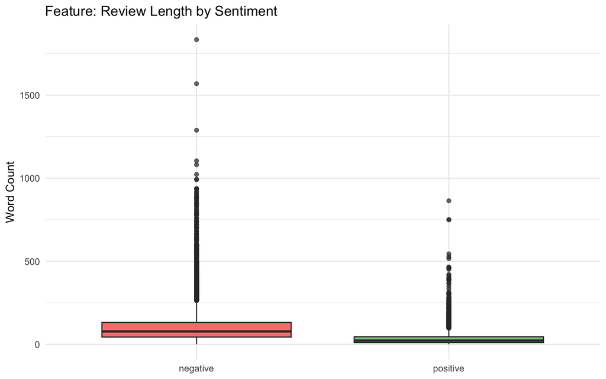

```r
# Feature: Review length by sentiment
ggplot(amazon_classification, aes(x = sentiment, y = word_count, fill = sentiment)) +
  geom_boxplot(alpha = 0.7) +
  labs(title = "Feature: Review Length by Sentiment",
       x = NULL, y = "Word Count") +
  scale_fill_manual(values = c("negative" = "#F44336", "positive" = "#4CAF50")) +
  theme_minimal() +
  theme(legend.position = "none")
```

## Split Data

**What we’re doing:** Splitting data into training (75%) and testing (25%)

**Key functions:** - `initial_split()` - from tidymodels package - `training()` - extract training data - `testing()` - extract testing data

```r
set.seed(2025)

split_class <- initial_split(
  amazon_classification,
  prop = 0.75,
  strata = sentiment
)

train_class <- training(split_class)
test_class <- testing(split_class)

cat("Training:", nrow(train_class), "| Test:", nrow(test_class), "\n")
```

```
## Training: 15127 | Test: 5043
```

```r
train_class %>% count(sentiment)
```

```
## # A tibble: 2 × 2
##   sentiment     n
##   <fct>     <int>
## 1 negative  10762
## 2 positive   4365
```

Each parameter: - `prop = 0.75`: Put 75% in training, 25% in testing - `strata = sentiment`: Maintains the 71/29 negative/positive ratio in BOTH sets - `set.seed(2025)`: Makes split reproducible (everyone gets same split)

**Why 75/25?** - **75% training**: Need enough data for model to learn good patterns - **25% testing**: Need enough data to reliably evaluate performance - Standard practice in machine learning - Could also use 80/20 or 70/30

**Check stratification worked:**

```r
cat("Training set distribution:\n")
```

```
## Training set distribution:
```

```r
train_class %>% count(sentiment) %>% mutate(pct = round(n/sum(n)*100, 1)) %>% print()
```

```
## # A tibble: 2 × 3
##   sentiment     n   pct
##   <fct>     <int> <dbl>
## 1 negative  10762  71.1
## 2 positive   4365  28.9
```

```r
cat("\nTest set distribution:\n")
```

```
##
## Test set distribution:
```

```r
test_class %>% count(sentiment) %>% mutate(pct = round(n/sum(n)*100, 1)) %>% print()
```

```
## # A tibble: 2 × 3
##   sentiment     n   pct
##   <fct>     <int> <dbl>
## 1 negative   3588  71.1
## 2 positive   1455  28.9
```

## Step 1: Text Preprocessing

**What we’re doing:** Defining HOW to convert text to numbers

**Key function:** `recipe()` - from tidymodels/textrecipes packages

**Explain the concept:** “A recipe is like a cooking recipe - it lists all the steps to transform raw ingredients (text) into a finished dish (numbers the model can use)”

```r
preprocess_class <- recipe(sentiment ~ review_text, data = train_class) %>%
  step_tokenize(review_text) %>%
  step_stopwords(review_text) %>%
  step_tokenfilter(review_text, max_tokens = 1000) %>%
  step_tfidf(review_text)

preprocess_class
```

[output not shown]

Each step:

1. `recipe(sentiment ~ review_text)`:
   - Formula: predict sentiment FROM review_text
   - Read as: “sentiment is predicted by review_text”
2. `step_tokenize(review_text)`:
   - Splits text into individual words
   - “I love this” → [“I”, “love”, “this”]
3. `step_stopwords(review_text)`:
   - Removes common words like “the”, “a”, “is”
   - [“I”, “love”, “this”] → [“love”]
4. `step_tokenfilter(review_text, max_tokens = 1000)`:
   - Keeps only the 1000 most frequent words
   - Reduces noise and computation time
   - “Why 1000?” - Balance between information and efficiency
5. `step_tfidf(review_text)`:
   - Calculates TF-IDF weights (importance scores)
   - Words unique to one class get higher weight

**Important:** This recipe is NOT applied yet - it’s just a plan!

## Step 2: Choose Model

**What we’re doing:** Choosing the algorithm to use

**Key function:** `logistic_reg()` - from tidymodels/parsnip package

```r
model_class <- logistic_reg() %>%
  set_engine("glm") %>%
  set_mode("classification")

model_class
```

```
## Logistic Regression Model Specification (classification)
##
## Computational engine: glm
```

Each component:

1. `logistic_reg()`:
   - Logistic Regression - a classification algorithm
   - Good for binary outcomes (positive vs negative)
   - Predicts PROBABILITY of each class
2. `set_engine("glm")`:
   - **glm** = Generalized Linear Model
   - The specific R function that will do the math
   - Other options: glmnet, keras, etc.
   - glm is simple and fast - good for learning!
3. `set_mode("classification")`:
   - Tells model we’re predicting CATEGORIES (not numbers)
   - For regression, we’d use `"regression"`

**Why logistic regression?** - Simple and interpretable - Fast to train - Works well for text classification - Industry standard for baseline models

## Step 3: Train the Model

**What we’re doing:** Combining preprocessing + model and training it

**Key concept: WORKFLOW** - Bundles preprocessing recipe + model together - Ensures preprocessing is applied consistently - Makes it easy to apply same steps to new data

**Key functions:** - `workflow()` - from tidymodels package - `add_recipe()` - adds preprocessing steps - `add_model()` - adds model specification - `fit()` - actually trains the model

```r
# Create workflow
pipeline_class <- workflow() %>%
  add_recipe(preprocess_class) %>%
  add_model(model_class)

pipeline_class
```

```
## ══ Workflow ════════════════════════════════════════════════════════════════════
## Preprocessor: Recipe
## Model: logistic_reg()
##
## ── Preprocessor ────────────────────────────────────────────────────────────────
## 4 Recipe Steps
##
## • step_tokenize()
## • step_stopwords()
## • step_tokenfilter()
## • step_tfidf()
##
## ── Model ───────────────────────────────────────────────────────────────────────
## Logistic Regression Model Specification (classification)
##
## Computational engine: glm
```

The workflow:

1. `workflow()`:
   - Creates empty workflow container
   - Think of it as an empty pipeline
2. `add_recipe(preprocess_class)`:
   - Adds our preprocessing steps
   - Remember: tokenize → remove stop words → filter → TF-IDF
3. `add_model(model_class)`:
   - Adds our logistic regression model
   - Now pipeline knows: preprocessing + what model to use

**Now train it:**

```r
fit_class <- pipeline_class %>%
  fit(data = train_class)

cat("Classification model trained!\n")
```

```
## Classification model trained!
```

What fit() does: - Takes our workflow (preprocessing + model) - Applies it to training data - Model LEARNS patterns from the data - This is where the “learning” happens! - May take 10-30 seconds depending on computer

**What happened:** 1. Converted all training reviews to TF-IDF vectors 2. Logistic regression found patterns: which words predict positive? negative? 3. Model now “knows” these patterns 4. Ready to make predictions on NEW data!

## Step 4: Make Predictions

**What we’re doing:** Using trained model to predict sentiment on TEST data

**Key function:** `predict()` - from tidymodels package

```r
pred_class <- fit_class %>%
  predict(new_data = test_class) %>%
  bind_cols(test_class)

# View some predictions
pred_class %>%
  select(review_text, sentiment, .pred_class) %>%
  slice_sample(n = 10)
```

```
## # A tibble: 10 × 3
##    review_text                                             sentiment .pred_class
##    <chr>                                                   <fct>     <fct>
##  1 Review text not found                                   negative  positive
##  2 Very poor ruined my birthday gift poor poor poor scamm… negative  negative
##  3 I have been a seller on Amazon for 6 months and my sto… negative  negative
##  4 The customer service representative was an absolute je… negative  negative
##  5 Garbage DeliveryI ordered an AC, But it never arrived,… negative  negative
##  6 I've been shopping with Amazon for years, and it's a g… positive  positive
##  7 Customer service representative spoke with very strong… negative  negative
##  8 I love Amazon when i need anything i can find it on th… positive  positive
##  9 Horrendous costumers service  still  waiting  my refun… negative  negative
## 10 Stupid Amazon App blocks you from reporting missing it… negative  negative
```

Each part:

1. `predict(new_data = test_class)`:
   - Applies model to NEW data (test set)
   - Returns predictions in column `.pred_class`
   - Model has NEVER seen this data before!
2. `bind_cols(test_class)`:
   - Attaches original data (actual sentiment)
   - So we can compare predicted vs actual
3. Columns in result:
   - `sentiment`: ACTUAL label (ground truth)
   - `.pred_class`: PREDICTED label (model’s guess)
   - `review_text`: The actual review

## Step 5: Evaluate Performance

**What we’re doing:** Measuring how well our model performs

### Confusion Matrix

**Key function:** `conf_mat()` - from yardstick package (part of tidymodels)

```r
conf_mat_class <- pred_class %>%
  conf_mat(truth = sentiment, estimate = .pred_class)

print(conf_mat_class)
```

```
##           Truth
## Prediction negative positive
##   negative     3361      188
##   positive      227     1267
```

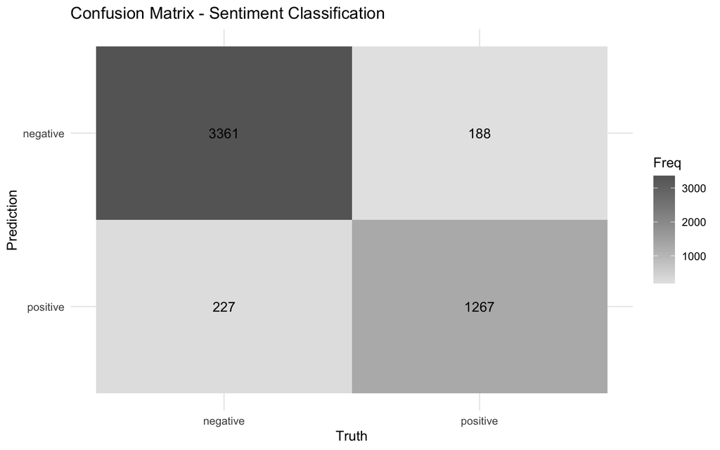

```r
autoplot(conf_mat_class, type = "heatmap") +
  labs(title = "Confusion Matrix - Sentiment Classification") +
  theme_minimal()
```

The confusion matrix:

```
                 Predicted
                 negative  positive
Actual negative    [TN]      [FP]
       positive    [FN]      [TP]
```

**Four outcomes:** 1. **True Negative (TN)**: Predicted negative, actually negative ✓ 2. **False Positive (FP)**: Predicted positive, actually negative ✗ (Type I error) 3. **False Negative (FN)**: Predicted negative, actually positive ✗ (Type II error) 4. **True Positive (TP)**: Predicted positive, actually positive ✓

### Performance Metrics

```r
metrics_class <- pred_class %>%
  metrics(truth = sentiment, estimate = .pred_class)

print(metrics_class)
```

```
## # A tibble: 2 × 3
##   .metric  .estimator .estimate
##   <chr>    <chr>          <dbl>
## 1 accuracy binary         0.918
## 2 kap      binary         0.801
```

```r
accuracy <- metrics_class %>% filter(.metric == "accuracy") %>% pull(.estimate)
cat("\nOverall Accuracy:", round(accuracy * 100, 2), "%\n")
```

```
##
## Overall Accuracy: 91.77 %
```

Each metric:

1. **Accuracy**: (TP + TN) / Total
   - What % of predictions were correct?
   - Easy to understand, but can be misleading with imbalanced data!
2. **Kappa**: Agreement beyond chance
   - Adjusts for class imbalance
   - Better metric for imbalanced data

**But wait! Compare to baseline:**

```r
baseline_accuracy <- neg_count / (neg_count + pos_count)
cat("\n=== Baseline Comparison ===\n")
```

```
##
## === Baseline Comparison ===
```

```r
cat("Baseline (always predict negative):", round(baseline_accuracy * 100, 2), "%\n")
```

```
## Baseline (always predict negative): 71.15 %
```

```r
cat("Our model:", round(accuracy * 100, 2), "%\n")
```

```
## Our model: 91.77 %
```

```r
cat("Improvement:", round((accuracy - baseline_accuracy) * 100, 2), "percentage points\n")
```

```
## Improvement: 20.63 percentage points
```

### Class-Specific Metrics

**Why important:** With imbalanced data, accuracy can be misleading

```r
class_metrics <- pred_class %>%
  precision(truth = sentiment, estimate = .pred_class) %>%
  bind_rows(pred_class %>% recall(truth = sentiment, estimate = .pred_class)) %>%
  bind_rows(pred_class %>% f_meas(truth = sentiment, estimate = .pred_class))

print(class_metrics)
```

```
## # A tibble: 3 × 3
##   .metric   .estimator .estimate
##   <chr>     <chr>          <dbl>
## 1 precision binary         0.947
## 2 recall    binary         0.937
## 3 f_meas    binary         0.942
```

**Trade-off:** High precision vs high recall - High precision: Few false positives (conservative) - High recall: Few false negatives (liberal)

## Step 6: Feature Importance

**What we’re doing:** Understanding WHICH words the model thinks are important

**Why important:** - Shows what the model learned - Helps interpret predictions - Can reveal biases or unexpected patterns

**Key function:** `extract_fit_parsnip()` then `tidy()` - from broom package

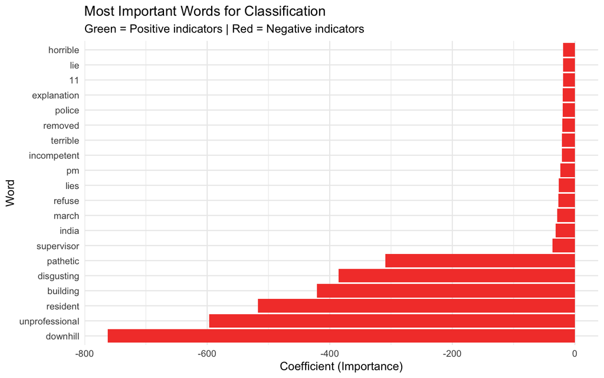

```r
coefs <- fit_class %>%
  extract_fit_parsnip() %>%
  tidy() %>%
  filter(term != "(Intercept)") %>%
  mutate(
    term = str_remove(term, "tfidf_review_text_"),
    abs_estimate = abs(estimate)
  )

# Top 20 most important words
top20 <- coefs %>% slice_max(abs_estimate, n = 20)

ggplot(top20, aes(x = reorder(term, estimate), y = estimate, fill = estimate > 0)) +
  geom_col() +
  coord_flip() +
  labs(title = "Most Important Words for Classification",
       subtitle = "Green = Positive indicators | Red = Negative indicators",
       x = "Word", y = "Coefficient (Importance)") +
  scale_fill_manual(values = c("TRUE" = "#4CAF50", "FALSE" = "#F44336")) +
  theme_minimal() +
  theme(legend.position = "none")
```

```r
cat("\n=== Top Positive Words ===\n")
```

```
##
## === Top Positive Words ===
```

```r
coefs %>% slice_max(estimate, n = 5) %>% select(term, estimate) %>% print()
```

```
## # A tibble: 5 × 2
##   term      estimate
##   <chr>        <dbl>
## 1 excellent     17.0
## 2 quickly       16.0
## 3 questions     14.4
## 4 love          14.1
## 5 great         13.0
```

```r
cat("\n=== Top Negative Words ===\n")
```

```
##
## === Top Negative Words ===
```

```r
coefs %>% slice_min(estimate, n = 5) %>% select(term, estimate) %>% print()
```

```
## # A tibble: 5 × 2
##   term           estimate
##   <chr>             <dbl>
## 1 downhill          -762.
## 2 unprofessional    -597.
## 3 resident          -517.
## 4 building          -421.
## 5 disgusting        -386.
```

Understanding coefficients:

1. **Positive coefficient**: Word increases probability of positive sentiment
   - “excellent” has positive coefficient → indicates positive review
2. **Negative coefficient**: Word decreases probability of positive sentiment (increases negative)
   - “terrible” has negative coefficient → indicates negative review
3. **Magnitude**: How strong the effect is
   - Larger absolute value = more important for classification
- “Do these words make sense?”
- “Any surprises?”
- “What does this tell us about customer reviews?”

**Important insight:** The model learned patterns from data, not pre-programmed rules!

# Part 5: REGRESSION (Optional - Self-Learning)

**What’s different:** - Predict rating (1-5) instead of sentiment (positive/negative) - Use `linear_reg()` instead of `logistic_reg()` - Evaluate with RMSE and R² instead of accuracy

```r
set.seed(2025)
split_reg <- initial_split(amazon_regression, prop = 0.75)
train_reg <- training(split_reg)
test_reg <- testing(split_reg)

preprocess_reg <- recipe(rating ~ review_text, data = train_reg) %>%
  step_tokenize(review_text) %>%
  step_stopwords(review_text) %>%
  step_tokenfilter(review_text, max_tokens = 1000) %>%
  step_tfidf(review_text)

model_reg <- linear_reg() %>%
  set_engine("lm") %>%
  set_mode("regression")

pipeline_reg <- workflow() %>%
  add_recipe(preprocess_reg) %>%
  add_model(model_reg)

fit_reg <- pipeline_reg %>%
  fit(data = train_reg)

pred_reg <- fit_reg %>%
  predict(new_data = test_reg) %>%
  bind_cols(test_reg)

metrics_reg <- pred_reg %>%
  metrics(truth = rating, estimate = .pred)

print(metrics_reg)
```

```
## # A tibble: 3 × 3
##   .metric .estimator .estimate
##   <chr>   <chr>          <dbl>
## 1 rmse    standard       1.08
## 2 rsq     standard       0.587
## 3 mae     standard       0.826
```

- **RMSE**: Average prediction error in stars (lower is better)
- **R²**: How much variance explained (higher is better, max = 1.0)

**Show plot:**

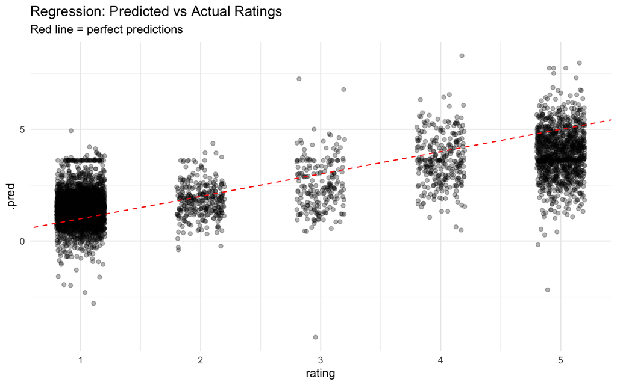

```r
ggplot(pred_reg, aes(x = rating, y = .pred)) +
  geom_jitter(alpha = 0.3, width = 0.2) +
  geom_abline(slope = 1, intercept = 0, color = "red", linetype = "dashed") +
  labs(title = "Regression: Predicted vs Actual Ratings",
       subtitle = "Red line = perfect predictions") +
  theme_minimal()
```

# Wrap-up

## Key Takeaways

**What we learned today:**

1. **Supervised Learning**: Learning from labeled examples
2. **Classification**: Predicting categories (positive vs negative)
3. **Train/Test Split**: Never test on training data! (75/25 split)
4. **Text Preprocessing**: Tokenize → Stop words → TF-IDF
5. **Evaluation**: Confusion matrix, accuracy, precision, recall
6. **Feature Importance**: Understanding what the model learned

## The Big Picture

**What SML does:** - Provides automated approach to process text as humans would manually - Machine learns RULES (patterns) that we define - Applies these rules to classification/regression tasks

**How to apply SML:** 1. Label some data (or use pre-labeled data) 2. Split into train/test sets 3. Define preprocessing steps 4. Train model on training data 5. Evaluate on test data 6. Interpret results

## Next Steps

- Try with your own text data!
- Experiment with different preprocessing (more/fewer tokens)
- Try different models (Random Forest, SVM)
- Learn about cross-validation for more robust evaluation

## Resources

- [Tidymodels](https://www.tidymodels.org/)
- [Text Mining with R](https://www.tidytextmining.com/)
- [Supervised ML for Text](https://smltar.com/)

*Tutorial by Sungwon Jung, J381M 2026*